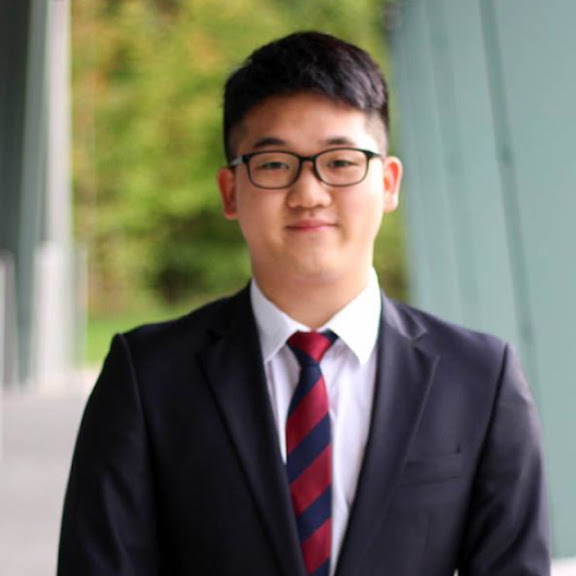

# Do Hyun David Park

## Bio

Growing up, the bill was scarier than the illness. My family immigrated without health insurance, so regular medical visits were out of reach. When my dad had a heart attack, I couldn’t stop wondering: “If we’d had insurance, would this have happened at all?” That question never left me and has shaped my career interest to be in preventive cardiology and immigrant health.

Currently, I am a part-time MPH student at the Johns Hopkins School of Public Health, concentrating in Epidemiology and Biostatistics. I hope to become a clinician and clinical epidemiologist who uses population-level research to improve cardiovascular outcomes for immigrant and underserved communities. I’m particularly interested in hypertension management, novel biomarkers, and community outreach.

Please download my CV to get details of my research, clinical, and public health experience

## Education

**Johns Hopkins University** | Baltimore, MD MPH in Epidemiology and Biostatistics | 2025 -

**University of California, Los Angeles** | Los Angeles, CA B.S. in Molecular, Cellular, & Developmental Biology | September 2016 - September 2020

## Hobbies

Few things make me happier than offering others hospitality. I love to cook a warm meal that reminds people of their homes. Similar to when Anton Ego had a bite of his *Ratatouille*.

I also enjoy taking photos, on film or digital, to capture memories. Lastly, I like to stay active either playing soccer, basketball, or lifting weights.

[figure not shown]

First: Soccer 2025; Middle: Sedona,Az 2021; Bottom: NYC 2025